# Lab 5

Muhamad Imran Bin Maszeri

11/9/2020

# Questions

```r
library(ggplot2)
library(tidyverse)
library(dplyr)
library(lubridate)
library(readxl)

acc <- read.csv("https://raw.githubusercontent.com/xdaiISU/ds202materials/master/hwlabs/fars2017/accident.csv", stringsAsFactors = FALSE)
person <- read.csv("https://raw.githubusercontent.com/xdaiISU/ds202materials/master/hwlabs/fars2017/person.csv", stringsAsFactors = FALSE)

str(acc)
```

```
## 'data.frame':    34247 obs. of  52 variables:
##  $ STATE     : int  1 1 1 1 1 1 1 1 1 1 ...
##  $ ST_CASE   : int  10001 10002 10003 10004 10005 10006 10007 10008 10009 10010 ...
##  $ VE_TOTAL  : int  1 1 3 1 1 2 2 1 1 1 ...
##  $ VE_FORMS  : int  1 1 3 1 1 2 2 1 1 1 ...
##  $ PVH_INVL  : int  0 0 0 0 0 0 0 0 0 0 ...
##  $ PEDS      : int  0 0 0 0 0 0 0 0 0 1 ...
##  $ PERNOTMVIT: int  0 0 0 0 0 0 0 0 0 1 ...
##  $ PERMVIT   : int  1 1 3 1 2 4 2 1 1 1 ...
##  $ PERSONS   : int  1 1 3 1 2 4 2 1 1 1 ...
##  $ COUNTY    : int  73 89 101 73 13 49 73 3 87 73 ...
##  $ CITY      : int  330 1730 2130 350 0 0 350 0 0 0 ...
##  $ DAY       : int  19 14 31 1 1 6 11 11 11 14 ...
##  $ MONTH     : int  2 2 1 1 1 1 1 1 1 1 ...
##  $ YEAR      : int  2017 2017 2017 2017 2017 2017 2017 2017 2017 2017 ...
```

[output cut: 38 more lines]

```r
str(person)
```

```
## 'data.frame':    84921 obs. of  68 variables:
##  $ STATE     : int  1 1 1 1 1 1 1 1 1 1 ...
##  $ ST_CASE   : int  10001 10002 10003 10003 10003 10004 10005 10005 10006 10006 ...
##  $ VE_FORMS  : int  1 1 3 3 3 1 1 1 2 2 ...
##  $ VEH_NO    : int  1 1 1 2 3 1 1 1 1 2 ...
##  $ PER_NO    : int  1 1 1 1 1 1 1 2 1 1 ...
##  $ STR_VEH   : int  0 0 0 0 0 0 0 0 0 0 ...
##  $ COUNTY    : int  73 89 101 101 101 73 13 13 49 49 ...
##  $ DAY       : int  19 14 31 31 31 1 1 1 6 6 ...
##  $ MONTH     : int  2 2 1 1 1 1 1 1 1 1 ...
##  $ HOUR      : int  23 14 20 20 20 16 20 20 18 18 ...
##  $ MINUTE    : int  35 59 31 31 31 55 0 0 40 40 ...
##  $ RUR_URB   : int  2 2 2 2 2 2 1 1 1 1 ...
##  $ FUNC_SYS  : int  1 1 1 1 1 4 1 1 1 1 ...
##  $ HARM_EV   : int  38 1 12 12 12 30 35 35 34 34 ...
```

[output cut: 54 more lines]

1. Are there some days of the week where more accidents happen than the others (see FARS manual, use variable DAY_WEEK)?

```r
acc$DAY_WEEK <- as.factor(acc$DAY_WEEK)
levels(acc$DAY_WEEK) <- c("Sun", "Mon", "Tue", "Wed", "Thu", "Fri", "Sat")

acc %>%
  group_by(DAY_WEEK) %>%
  summarise(total_accidents=n()) %>%
  arrange(desc(total_accidents))
```

```
## # A tibble: 7 x 2
##   DAY_WEEK total_accidents
##   <fct>              <int>
## 1 Sat                 5873
## 2 Sun                 5360
## 3 Fri                 5358
## 4 Thu                 4621
## 5 Mon                 4374
## 6 Tue                 4347
## 7 Wed                 4314
```

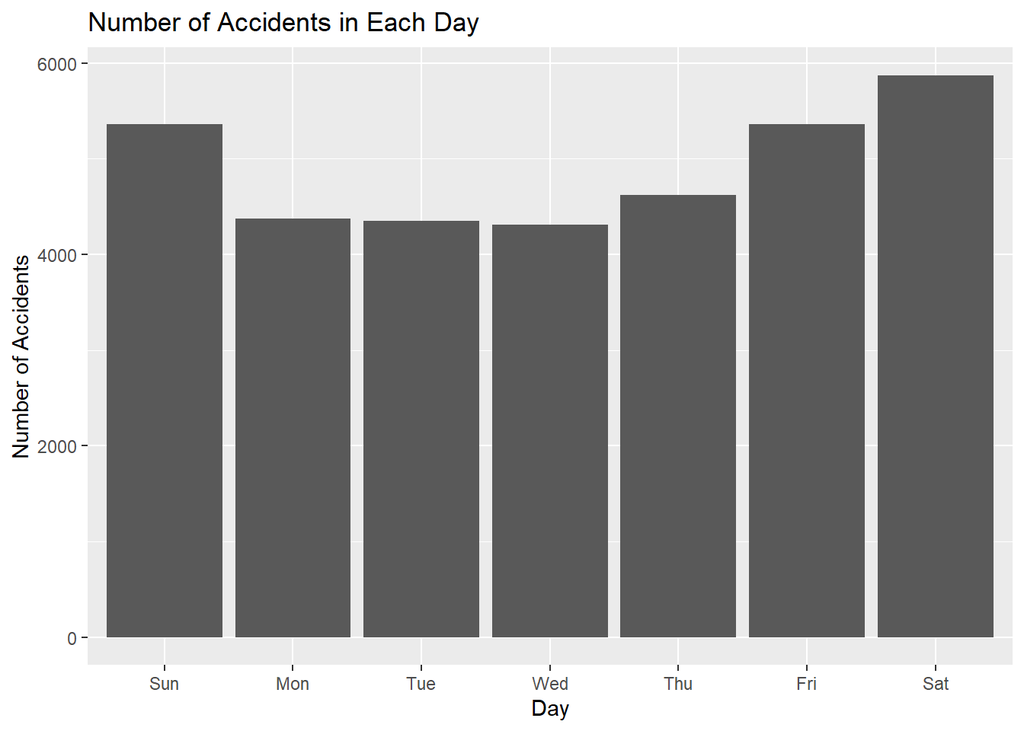

```r
acc %>%
  ggplot(aes(DAY_WEEK)) + geom_bar() + labs(x='Day', y='Number of Accidents', title='Number of Accidents in Each Day')
```

2. Create a data frame containing the persons who are fatally hurt in the accidents (look up variable INJ_SEV)

```r
fatal <- person %>%
  filter(INJ_SEV==4)
str(fatal)
```

```
## 'data.frame':    37133 obs. of  68 variables:
##  $ STATE     : int  1 1 1 1 1 1 1 1 1 1 ...
##  $ ST_CASE   : int  10001 10002 10003 10004 10005 10006 10007 10008 10009 10011 ...
##  $ VE_FORMS  : int  1 1 3 1 1 2 2 1 1 2 ...
##  $ VEH_NO    : int  1 1 2 1 1 1 1 1 1 1 ...
##  $ PER_NO    : int  1 1 1 1 1 1 1 1 1 1 ...
##  $ STR_VEH   : int  0 0 0 0 0 0 0 0 0 0 ...
##  $ COUNTY    : int  73 89 101 73 13 49 73 3 87 87 ...
##  $ DAY       : int  19 14 31 1 1 6 11 11 11 15 ...
##  $ MONTH     : int  2 2 1 1 1 1 1 1 1 1 ...
##  $ HOUR      : int  23 14 20 16 20 18 17 16 14 4 ...
##  $ MINUTE    : int  35 59 31 55 0 40 57 50 30 35 ...
##  $ RUR_URB   : int  2 2 2 2 1 1 2 1 1 2 ...
##  $ FUNC_SYS  : int  1 1 1 4 1 1 1 1 1 1 ...
##  $ HARM_EV   : int  38 1 12 30 35 34 12 35 21 12 ...
```

[output cut: 54 more lines]

3. Create a data frame containing the most dangerous vehicle make in each state. The number of persons fatally hit in the vehicle make is used to assess the (non-)safety of a make. Make sure to handle the missing values appropriately. (look up variable MAKE)

```r
danger_vehicle <- person %>%
  filter(INJ_SEV==4) %>%
  group_by(STATE, MAKE) %>%
  drop_na() %>%
  summarise(danger=n()) %>%
  group_by(STATE) %>%
  filter(danger==max(danger))

danger_vehicle <- danger_vehicle %>%
  filter(!((STATE==8 & MAKE==37) | (STATE==34 & MAKE==37) | (STATE==50 & MAKE==37)))

danger_vehicle
```

```
## # A tibble: 51 x 3
## # Groups:   STATE [51]
##    STATE  MAKE danger
##    <int> <int>  <int>
##  1     1    12    138
##  2     2    12      9
##  3     4    20     88
##  4     5    20     88
##  5     6    49    351
##  6     8    12     63
##  7     9    37     28
##  8    10    37     12
##  9    11    37      5
## 10    12    12    237
## # ... with 41 more rows
```

4. Create a map, and label each state with the most dangerous vehicle. Discuss the definition of the most dangerous vehicle, and what you find from the map. (Hint: Read the description for the STATE and COUNTY columns in the FARS manual. The state & county codes are Geographic Locator Codes (GLCs) from the General Services Administration’s (GSA) publication. Use readxl::read_xlsx to read in the GLCs.)

```r
GLC_USA <- read_xlsx("FRPP_GLC_-_United_StatesSep292020.xlsx")
GLC_USA <- GLC_USA %>%
  mutate(STATE=as.numeric(`State Code`)) %>%
  mutate(COUNTY=as.numeric(`County Code`)) %>%
  mutate(region=tolower(`State Name`)) %>%
  select(!c(`State Code`, `County Code`, `State Name`))

GLC_dat <- data.frame(GLC_USA)

USA_states <- map_data("state")

str(GLC_dat)
```

```
## 'data.frame':    39737 obs. of  11 variables:
##  $ Territory        : chr  "U" "U" "U" "U" ...
##  $ City.Code        : chr  "10" "50" "60" "0070" ...
##  $ City.Name        : chr  "ABBEVILLE" "ALBERTVILLE" "ALEXANDER CITY" "ALICEVILLE" ...
##  $ County.Name      : chr  "HENRY" "MARSHALL" "TALLAPOOSA" "PICKENS" ...
##  $ Country.Code     : chr  "840" "840" "840" "840" ...
##  $ Old.City.Name    : chr  NA NA NA NA ...
##  $ Date.Record.Added: logi  NA NA NA NA NA NA ...
##  $ Duty.Station.Code: chr  "010010067" "010050095" "010060123" "010070107" ...
##  $ STATE            : num  1 1 1 1 1 1 1 1 1 1 ...
##  $ COUNTY           : num  67 95 123 107 39 77 15 15 109 95 ...
##  $ region           : chr  "alabama" "alabama" "alabama" "alabama" ...
```

```r
str(USA_states)
```

```
## 'data.frame':    15537 obs. of  6 variables:
##  $ long     : num  -87.5 -87.5 -87.5 -87.5 -87.6 ...
##  $ lat      : num  30.4 30.4 30.4 30.3 30.3 ...
##  $ group    : num  1 1 1 1 1 1 1 1 1 1 ...
##  $ order    : int  1 2 3 4 5 6 7 8 9 10 ...
##  $ region   : chr  "alabama" "alabama" "alabama" "alabama" ...
##  $ subregion: chr  NA NA NA NA ...
```

```r
danger_vehicle <- data.frame(danger_vehicle)

factor(danger_vehicle$MAKE)
```

```
##  [1] 12 12 20 20 49 12 37 37 37 12 12 49 12 20 20 20 20 20 20 20 37 12 12 20 20
## [26] 20 20 20 12 49 12 12 20 12 20 20 20 12 20 49 12 20 20 12 12 20 12 20 20 20
## [51] 12
## Levels: 12 20 37 49
```

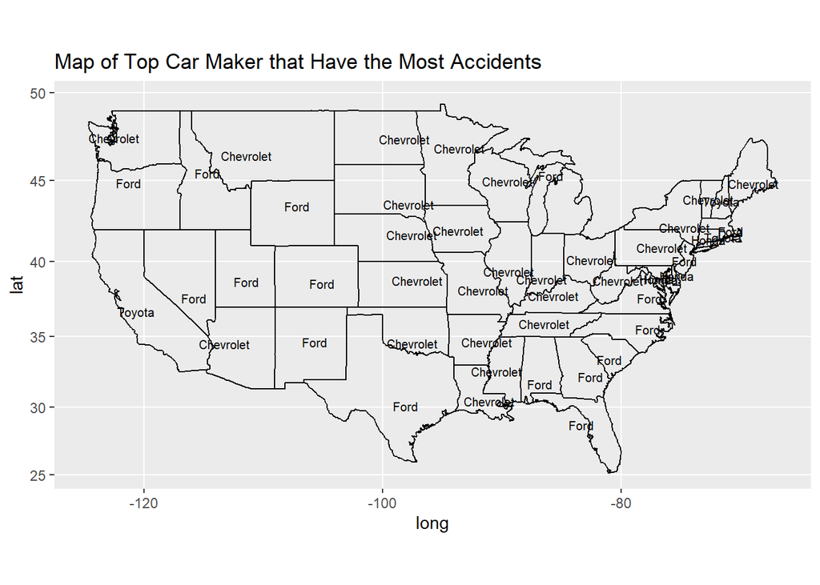

```r
danger_vehicle$MAKE <- as.factor(danger_vehicle$MAKE)
levels(danger_vehicle$MAKE) <- c("Ford", "Chevrolet", "Honda", "Toyota")

danger_state <- danger_vehicle %>%
  left_join(GLC_dat, by='STATE', 'COUNTY') %>%
  left_join(USA_states, by='region')

dan_text <- danger_state %>%
  group_by(STATE, MAKE) %>%
  summarise(long=mean(long), lat=mean(lat))

USA_states %>%
  ggplot(aes(x=long, y=lat)) + geom_path(aes(group=group)) + geom_path(aes(group=group)) + geom_text(data=dan_text, aes(x=long, y=lat, label=MAKE), size=2.7) + coord_map() + labs(title='Map of Top Car Maker that Have the Most Accidents')
```

5. Join the accident and person table (work out which variable(s) to use)

```r
join_dat <- acc %>%
  inner_join(person, by='ST_CASE')

str(join_dat)
```

```
## 'data.frame':    84921 obs. of  119 variables:
##  $ STATE.x   : int  1 1 1 1 1 1 1 1 1 1 ...
##  $ ST_CASE   : int  10001 10002 10003 10003 10003 10004 10005 10005 10006 10006 ...
##  $ VE_TOTAL  : int  1 1 3 3 3 1 1 1 2 2 ...
##  $ VE_FORMS.x: int  1 1 3 3 3 1 1 1 2 2 ...
##  $ PVH_INVL  : int  0 0 0 0 0 0 0 0 0 0 ...
##  $ PEDS      : int  0 0 0 0 0 0 0 0 0 0 ...
##  $ PERNOTMVIT: int  0 0 0 0 0 0 0 0 0 0 ...
##  $ PERMVIT   : int  1 1 3 3 3 1 2 2 4 4 ...
##  $ PERSONS   : int  1 1 3 3 3 1 2 2 4 4 ...
##  $ COUNTY.x  : int  73 89 101 101 101 73 13 13 49 49 ...
##  $ CITY      : int  330 1730 2130 2130 2130 350 0 0 0 0 ...
##  $ DAY.x     : int  19 14 31 31 31 1 1 1 6 6 ...
##  $ MONTH.x   : int  2 2 1 1 1 1 1 1 1 1 ...
##  $ YEAR      : int  2017 2017 2017 2017 2017 2017 2017 2017 2017 2017 ...
```

[output cut: 86 more lines]

6. Tally the number of accidents by day of the week (DAY_WEEK), hour of the day (HOUR) and gender (SEX). Visualize the results.

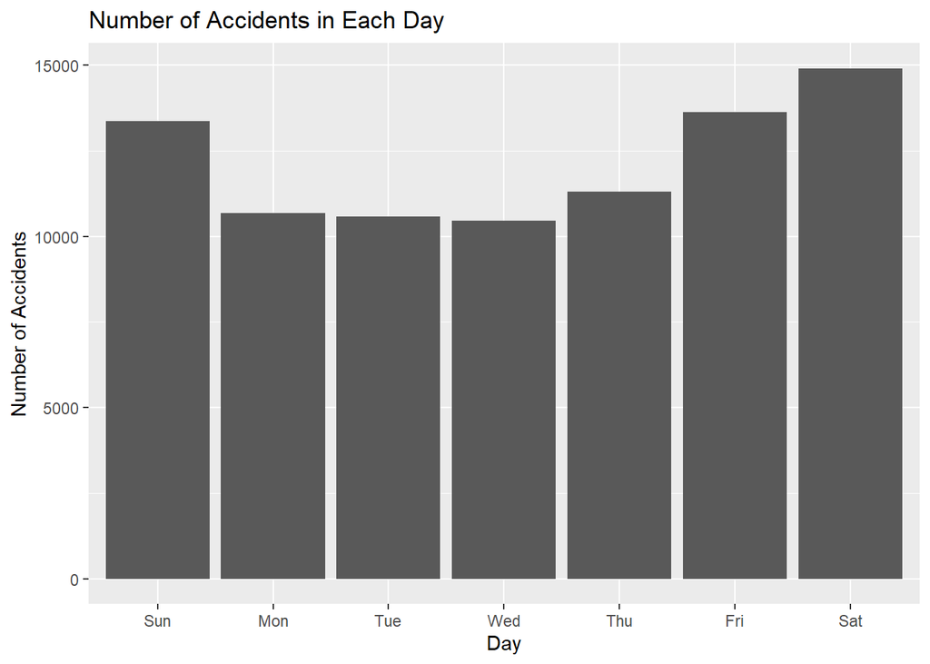

```r
join_dat %>%
  group_by(DAY_WEEK) %>%
  tally() %>%
  ggplot(aes(x=DAY_WEEK, y=n)) + geom_bar(stat = 'identity') + labs(x='Day', y='Number of Accidents', title='Number of Accidents in Each Day')
```

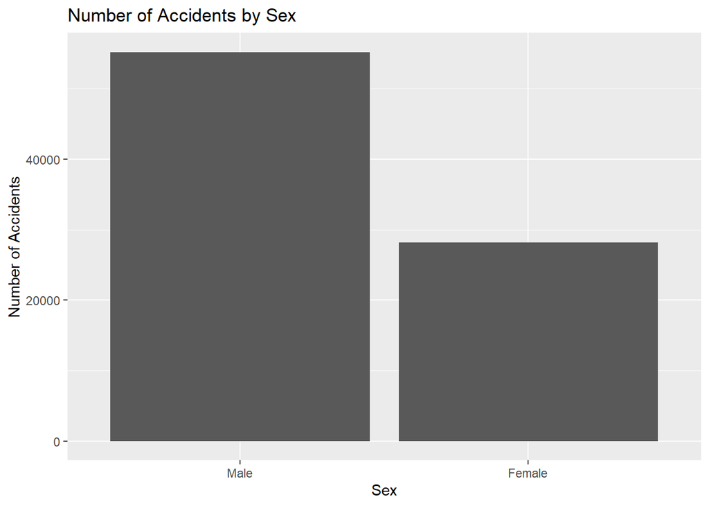

```r
join_dat$SEX <- as.factor(join_dat$SEX)
levels(join_dat$SEX) <- c("Male", "Female", "Not Reported", "Unknown")
join_dat %>%
  filter(!((SEX=="Not Reported") | (SEX=="Unknown"))) %>%
  group_by(SEX) %>%
  tally() %>%
  ggplot(aes(x=SEX, y=n)) + geom_bar(stat = 'identity') + labs(x='Sex', y='Number of Accidents', title='Number of Accidents by Sex')
```

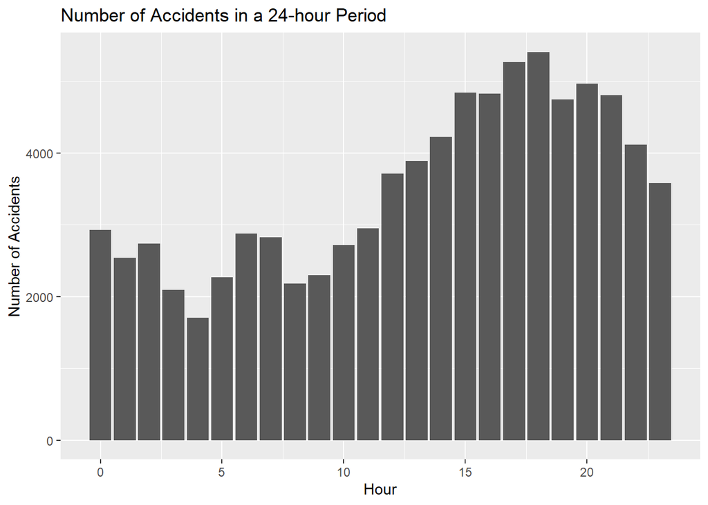

```r
join_dat %>%
  filter(!((HOUR.x==99) | (HOUR.x==88))) %>%
  group_by(HOUR.x) %>%
  tally() %>%
  ggplot(aes(x=HOUR.x, y=n)) + geom_bar(stat = 'identity') + labs(x='Hour', y='Number of Accidents', title='Number of Accidents in a 24-hour Period')
```

7. Now plot a choropleth map of the number of deaths on a county level.

```r
county <- map_data("county")

county_sum <- acc %>%
  group_by(COUNTY) %>%
  summarise(death=sum(FATALS))

county_death <- county_sum %>%
  inner_join(GLC_dat, by='COUNTY') %>%
  mutate(subregion=tolower(`County.Name`)) %>%
  select(!County.Name) %>%
  inner_join(county, by='subregion')


str(county_death)
```

```
## tibble [5,670,274 x 17] (S3: tbl_df/tbl/data.frame)
##  $ COUNTY           : num [1:5670274] 1 1 1 1 1 1 1 1 1 1 ...
##  $ death            : int [1:5670274] 830 830 830 830 830 830 830 830 830 830 ...
##  $ Territory        : chr [1:5670274] "U" "U" "U" "U" ...
##  $ City.Code        : chr [1:5670274] "220" "220" "220" "220" ...
##  $ City.Name        : chr [1:5670274] "AUTAUGAVILLE" "AUTAUGAVILLE" "AUTAUGAVILLE" "AUTAUGAVILLE" ...
##  $ Country.Code     : chr [1:5670274] "840" "840" "840" "840" ...
##  $ Old.City.Name    : chr [1:5670274] NA NA NA NA ...
##  $ Date.Record.Added: logi [1:5670274] NA NA NA NA NA NA ...
##  $ Duty.Station.Code: chr [1:5670274] "010220001" "010220001" "010220001" "010220001" ...
##  $ STATE            : num [1:5670274] 1 1 1 1 1 1 1 1 1 1 ...
##  $ region.x         : chr [1:5670274] "alabama" "alabama" "alabama" "alabama" ...
##  $ subregion        : chr [1:5670274] "autauga" "autauga" "autauga" "autauga" ...
##  $ long             : num [1:5670274] -86.5 -86.5 -86.5 -86.6 -86.6 ...
##  $ lat              : num [1:5670274] 32.3 32.4 32.4 32.4 32.4 ...
##  $ group            : num [1:5670274] 1 1 1 1 1 1 1 1 1 1 ...
##  $ order            : int [1:5670274] 1 2 3 4 5 6 7 8 9 10 ...
##  $ region.y         : chr [1:5670274] "alabama" "alabama" "alabama" "alabama" ...
```

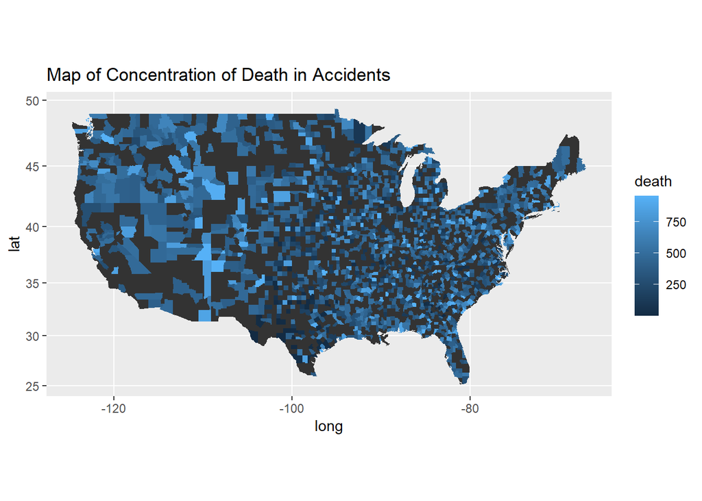

```r
county %>%
  ggplot(aes(x=long, y=lat)) + geom_polygon(aes(group=group)) + geom_polygon(data=county_death, aes(x=long, y=lat, group=group, fill=death)) + coord_map() + labs(title='Map of Concentration of Death in Accidents')
```

8. Is summer or winter more dangerous? Does this depend on states? Explore and explain.

```r
summer <- acc %>%
  filter(MONTH==6 | MONTH==7 | MONTH==8)

summer %>% summarise(sum=n())
```

```
##    sum
## 1 9205
```

```r
summer_state <- summer %>%
  group_by(STATE) %>%
  summarise(total=n()) %>%
  arrange(desc(total)) %>%
  head(5)

summer_state
```

```
## # A tibble: 5 x 2
##   STATE total
##   <int> <int>
## 1     6   871
## 2    48   841
## 3    12   675
## 4    13   361
## 5    42   325
```

```r
winter <- acc %>%
  filter(MONTH==1 | MONTH==2 | MONTH==12)

winter %>% summarise(sum=n())
```

```
##    sum
## 1 7733
```

```r
winter_state <- winter %>%
  group_by(STATE) %>%
  summarise(total=n()) %>%
  arrange(desc(total)) %>%
  head(5)

winter_state
```

```
## # A tibble: 5 x 2
##   STATE total
##   <int> <int>
## 1    48   791
## 2     6   785
## 3    12   768
## 4    13   344
## 5    37   320
```

Answer: Summer is more dangerous with more accidents with 9205 accidents, and Texas and California are both at the top in both seasons, so it does not matter whether any season happen, these 2 states will be on the top accidents.